# Module 9 Lecture - One Sample Z-tests and T-tests

Introduction to Statistical Methods

Quinton Quagliano, M.S., C.S.P

Department of Educational Psychology

# 1 Overview and Introduction

Agenda

1 Overview and Introduction

2 Null and Alternative Hypotheses

3 Outcomes and the Type I and Type II Errors

4 Probability Distribution Needed for Hypothesis Testing

5 Rare Events, the Sample, Decision, and Conclusion

6 Conclusion

## 1.1 Textbook Learning Objectives

- Differentiate between Type I and Type II Errors
- Describe hypothesis testing in general and in practice
- Conduct and interpret hypothesis tests for a single population mean, population standard deviation known.
- Conduct and interpret hypothesis tests for a single population mean, population standard deviation unknown.
- Conduct and interpret hypothesis tests for a single population proportion.

## 1.2 Instructor Learning Objectives

- Be able to identify different parts of a hypothesis given a narrative example
- Understand the connection between $\alpha$, p-values, probability, and Type I and II errors
- Be able to work through practical inferential statistics computations for a single sample scenario

## 1.3 Introduction

- In statistics, **hypothesis testing** is the process by which we evaluate whether data supports making a certain conclusion beyond a reasonable doubt
- We have certain steps to work through a hypothesis test:
  - Set up the contradictory null and alternative hypotheses
  - Collect data in a sample
  - Determine an appropriate inferential test and distribution to represent our variables
  - Conclude whether we can reject the null hypothesis or if we cannot
- **Important: I think it's important to emphasize that it is not our 'goal' to reject the null hypothesis - as empiricists, our orientation should be towards truth, not a certain outcome**

# 2 Null and Alternative Hypotheses

Agenda

1 Overview and Introduction

2 Null and Alternative Hypotheses

3 Outcomes and the Type I and Type II Errors

4 Probability Distribution Needed for Hypothesis Testing

5 Rare Events, the Sample, Decision, and Conclusion

6 Conclusion

## 2.1 Introduction

- A **hypothesis** is just a prediction or a statement of a possible outcome
  - E.g., I *hypothesize (or predict)* that college students who are Gen Z have significantly worse attention than Millennial college students
  - Most scientific studies begin with some hypothesis of what outcomes will look like
- **Discuss: Consider that you are a middle-school teacher being asked by administration to implement an especially permissive attendance structure, write a hypothesis of what this will do to student math scores**
- When we make hypotheses in statistics, we do so in a contradictory pair by making a null hypothesis and an alternative hypothesis
  - In frequentist statistical testing, we frame our inferential tests as helping us determine whether to reject the null - there is a whole other field of statistics called Bayesian statistics that has a somewhat different focus
- **Important: It's important to understand that, as part of the statistical testing process, we should always consider what our null and alternative hypothesis is!**

## 2.2 Null Hypotheses

- A **null hypothesis** is a prediction or statement of no difference between two or more things
  - It is usually written as $H_0$
  - Opposite of alternative hypothesis
- A null hypothesis is often written to include an equal sign such as with:
  - $=$
  - But also, $\geq$ & $\leq$
- Example: There is *no* difference in average attention between Gen Z and Millennial college students
  - Represented in notation $H_0: Attention_{Z} = Attention_{Millennial}$
- **Discuss: Write the null hypothesis for comparing mental health between women and men in the legal field, where they have equal levels of depression**

## 2.3 Alternative Hypotheses

- Our **alternative hypothesis** suggests a difference between two or more things
  - It is most often represented as $H_A$ or $H_1$
  - Opposite of Null Hypothesis
  - This is usually close to how we would phrase a study hypothesis
- The alternative hypothesis does *not* contain equal signs
  - This would include $\neq$, $>$, and $<$
- Example: There *is* a difference between Gen Z and Millennial college students in attention
  - Represented in notation $H_A: Attention_{Z} \neq Attention_{Millennial}$
- **Discuss: Write the alternative hypothesis for comparing mental health between women and men in the legal field, where women have higher levels of depression**

# 3 Outcomes and the Type I and Type II Errors

Agenda

1 Overview and Introduction

2 Null and Alternative Hypotheses

3 Outcomes and the Type I and Type II Errors

4 Probability Distribution Needed for Hypothesis Testing

5 Rare Events, the Sample, Decision, and Conclusion

6 Conclusion

## 3.1 Decision-making

- When we gather and analyze the data we gather from a sample, we use those results to make a **decision**
  - The decision comes down to whether we can reject the null hypothesis or not (sometimes called ‘retaining’ the null hypothesis)
  - Ideally we avoid making a type I or type II error with our decision

| **Reality (Truth)** | **Decision: Reject H₀** | **Decision: Fail to Reject H₀** |
| --- | --- | --- |
| **H₀ is True** | **Type I Error (α)** False positive | **Correct Decision** (True negative) |
| **H₁ is True** | **Correct Decision** (True positive) | **Type II Error (β)** False negative |

## 3.2 Types of Errors

- A **type I error** is when we decide to reject the null hypothesis, when it is actually true
  - The probability of a Type I error occurring (i.e., $P(TypeI)$) is given as $\alpha$
- **Discuss: Review: where did we come across alpha before? Explain it's significance in the context of module 8!**
- A **type II error** is when we decide to retain the null hypothesis when it is actually false
  - The probability of a Type II error occurring (i.e., $P(TypeII)$) is given as $\beta$
- **Important: When I was first trained on statistics, I was taught to view the Type I error as being more 'egregious' - 'the number one error to avoid!' - but realistically, they both result in flawed conclusions which could be dangerous**
- Ideally, both $\alpha$ and $\beta$ should be as small as possible, as to try an avoid making an error of any sort!
  - An extension of this is that **power**, the likelihood we correctly reject the null when it is false
  - $Power = 1 - \beta$
- **Question: In a hypothetical experiment when comparing students before and after a new instructional style, I correctly decide I can reject the null hypothesis that there was no change. This is accurate, as there actually was a change. What error occurred here?**
- A) No error occurred
- B) Type I
- C) Type II
- D) Not enough information

# 4 Probability Distribution Needed for Hypothesis Testing

Agenda

1 Overview and Introduction

2 Null and Alternative Hypotheses

3 Outcomes and the Type I and Type II Errors

4 Probability Distribution Needed for Hypothesis Testing

5 Rare Events, the Sample, Decision, and Conclusion

6 Conclusion

## 4.1 Introduction

- Its important that we identify the sampling probability distribution we can use to represent a certain variable and it’s mean or proportion
  - Effectively, this is where we are choosing a test - a very important step in our analysis!
- **Important: Choosing the 'right' test for certain situations is probably the most valuable skill a statistician has!**
- **Discuss: Review: What is the formula for the SE of the mean and how does that tie back to the normal distribution of sample means?**

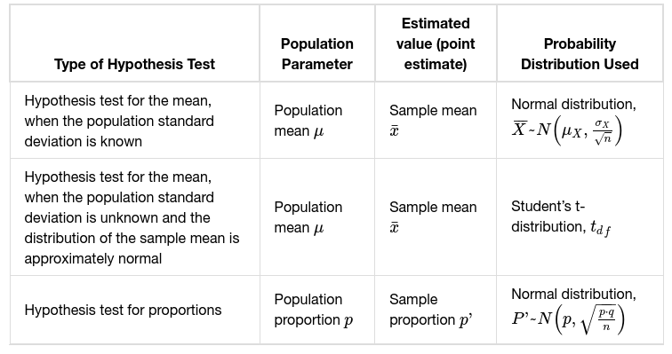

## 4.2 Assumptions

- An **assumption** is some prerequisite of the distribution we are using
- Take for example: the z-test for a population mean with the normal distribution. We need:
  - $\mu$, $\sigma$, and the population must be normally distributed / large enough to appeal to the CLT
  - We must also have a simple random sample from the population
- **Discuss: Review: Describe why a simple random sample is often impractical. This is where research design intersects with analysis!**
- The t-test for a population mean with the t-distribution assumes we also have a simple random sample from a normally distributed population
- **Important: Different inferential tests have different assumptions, and violating those assumptions can have big consequences! Too many researchers outright ignore these for convenience**

# 5 Rare Events, the Sample, Decision, and Conclusion

Agenda

1 Overview and Introduction

2 Null and Alternative Hypotheses

3 Outcomes and the Type I and Type II Errors

4 Probability Distribution Needed for Hypothesis Testing

5 Rare Events, the Sample, Decision, and Conclusion

6 Conclusion

## 5.1 Introduction

- While accounting for the information, statistics, parameters, and sampling distribution we have do help us make good choices about hypothesis testing - they don’t tell us everything
  - We always have to remember that things in statistics are probabilistic!
  - With our sampling and data gathering we may run into a **rare event**
- To account for the possibility of a rare event, we test the null hypothesis somehow
- **Discuss: Try re-explaining, in your own words, what 'probablistic' means and why it's readily applicable to the practice of statistics**

## 5.2 Using the Sample to Test the Null Hypothesis

- This is where we introduce the **p-value**, which is the chance that, under the null hypothesis being true, our results will be as extreme as they are
  - Example: a test result returns a p-value of 0.07. Assuming the null hypothesis is true, this result only had a 7% chance of occurring.
- Effectively, when we test against the null hypothesis and determine a p-value, we are trying to gauge how likely our results were to occur if the null hypothesis was true
  - If our results are especially rare under the null hypothesis (i.e., a low p-value), then we may be inclined to believe that our case is somehow truly different, and thus the null hypothesis is incorrect and can be rejected
- **Important: There are many misunderstandings people have about statistics, but failing to understand the meaning of p-values is probably the single most common and pervasive errors people make in interpreting statistics.**

## 5.3 Decision and Conclusion

- How do we determine if the p-value is, “rare enough”?
  - Ideally, we test it against a preset/preconceived **significance level**, also given as $\alpha$.
  - We decide whether our p-value is $\geq$ or $<$ our $\alpha$
- **Important: This is the exact same alpha that showed up in regard to confidence level in the last module and earlier in our Type I error! We *choose* what we wish our significance level to be at the onset of our analyses.**
- If you don’t see further information, the most common significance level is $\alpha = 0.05$
  - However, this isn’t a hard set rule.
- **Discuss: Take a look at the prior discussion on Type I and Type II error - try using those terms to discuss why have too high of an alpha level might be risky**

## 5.4 Tails of a Test

- A test may be described as two-tailed, left-tailed, or right-tailed, dependent on the sign used in the alternative hypothesis
  - $H_a: P > 0.5 \rightarrow$ right-tailed (one-tailed)
  - $H_a: P < 0.5 \rightarrow$ left-tailed (one-tailed)
  - $H_a: P \neq 0.5 \rightarrow$ two-tailed
- This needs to be set as part of the study set up, not during analysis!
- **Discuss: Consider the following example: Johnny predicts that Samantha has more money than Becky right now. Is this a one-tailed or two-tailed test and why?**

# 6 Conclusion

Agenda

1 Overview and Introduction

2 Null and Alternative Hypotheses

3 Outcomes and the Type I and Type II Errors

4 Probability Distribution Needed for Hypothesis Testing

5 Rare Events, the Sample, Decision, and Conclusion

6 Conclusion

## 6.1 Recap

- Hypothesis testing is the backbone of inferential statistics, and testing against the null hypothesis is how we determine whether our results were just a chance “fluke” or likely some real difference!
- Proper hypothesis testing hinges upon wise identification of what values we have and what distribution best describes our variables. Each distribution and test we could use has a set of assumptions we need to be aware of
- P-values, alpha, beta, and the two hypotheses are all connected, and we must be careful to make the correct decisions - wary of the relative risk of Type I and Type II errors

## 6.2 Lecture Check-in

- Make sure to complete any lecture check-in tasks associated with this lecture!

[figure not shown]

Module 9 Lecture - One Sample Z-tests and T-tests || Introduction to Statistical Methods